# Lab 3: Reproducibility, Experiment Management, and Hyperparameter Search

**Course: Software Tools and Techniques for AI (CS 203)**

Context: A student trains a model, gets 87% accuracy, and is happy. Two weeks later the professor asks: *"How did you get 87%?"* The student runs the code again and gets 81%. Nobody knows why. The result is lost. This lab makes sure that never happens to you: you will learn to make every run repeatable and recorded, then search for the best settings in a smart way instead of guessing - first by understanding what the search algorithms actually do (by building two of them yourself), then by using the industry-standard tools that do it for you.

**Running task:** predict whether a breast tumor is **malignant** or **benign** from 30 measurements taken from a cell nucleus image (radius, texture, smoothness, concavity, and so on). We use the **Breast Cancer Wisconsin (Diagnostic)** dataset, built into scikit-learn - it needs no download, no API key, and no output from a previous lab, so class time goes to reproducibility and search, not data wrangling. A few Extension exercises bring in other built-in scikit-learn datasets (Wine, California Housing) to test whether what you learned generalises beyond one dataset.

> **Instructor solution notebook.** Every `# TODO` cell from the exercise notebook is filled in below with a reference solution. Section 13 (AutoGluon) and Section 14 (Weights & Biases) call external services that need a package install / a free account and logi - the code is correct and runnable, but results (leaderboards, sweep charts) will differ run to run and cannot be pre-baked into this file. TrackIO (Section 7) is local-first and needs no account, so its outputs are fully deterministic. Do not distribute this notebook to students.

# 1. Import Libraries

Before doing anything else, we import the libraries this lab needs and set up the Kaggle environment.

### Why these libraries?

- **NumPy / pandas** — numerical arrays and tabular data.
- **Matplotlib** — plotting learning curves, heatmaps, and search results.
- **json / time / os / platform / subprocess / datetime** — the plumbing behind reproducibility: writing config files, timing runs, reading library versions, calling `git`, and timestamping experiments.

### Learning Outcomes

- Import the libraries used throughout this lab.
- Understand what each one is for before it shows up in later sections.

```python
# This Python 3 environment comes with many helpful analytics libraries installed
# It is defined by the kaggle/python Docker image: https://github.com/kaggle/docker-python

import numpy as np
import pandas as pd
import matplotlib.pyplot as plt
import os

# Input data files (if any are attached) are available in the read-only "../input/" directory
for dirname, _, filenames in os.walk('/kaggle/input'):
    for filename in filenames:
        print(os.path.join(dirname, filename))

# You can write up to 20GB to /kaggle/working/, which is preserved as output
# when you create a version using "Save & Run All"

# scikit-learn, pandas, numpy, matplotlib, and joblib are already installed.
# optuna, autogluon.tabular, wandb, and trackio are NOT preinstalled on Kaggle
# - each is installed right where it's first used, not here, so you only pay
# the install cost for the sections you actually run.
```

```python
import json, time, os, platform, subprocess
from pathlib import Path
from datetime import datetime

RUNS_DIR = Path("/kaggle/working/runs"); RUNS_DIR.mkdir(parents=True, exist_ok=True)
```

# 2. Load Dataset

We use the **Breast Cancer Wisconsin (Diagnostic)** dataset. It ships inside scikit-learn, so there is nothing to download or attach — `load_breast_cancer()` returns 569 samples, 30 numeric features per sample (radius, texture, perimeter, area, smoothness, concavity, ... each reported as a mean, a standard error, and a "worst" value), and a binary target: malignant or benign.

### Why a built-in dataset for this lab?

This lab is about **how you train**, not about the data itself — seeds, environments, experiment logs, and search strategies work the same way regardless of what the data looks like. A dataset that loads in one line with zero wrangling means class time goes to those concepts instead of data engineering.

### Learning Outcomes

- Load a dataset directly from scikit-learn.
- Understand the shape of the data you will be training on for the rest of the lab.

```python
from sklearn.datasets import load_breast_cancer

data = load_breast_cancer(as_frame=True)
df = data.frame.copy()
df["diagnosis"] = df["target"].map({0: "malignant", 1: "benign"})
df = df.drop(columns=["target"])
print(df.shape)
df.head()
```

```
(569, 31)
```

|  | mean radius | mean texture | mean perimeter | mean area | mean smoothness | mean compactness | mean concavity | mean concave points | mean symmetry | mean fractal dimension | ... | worst texture | worst perimeter | worst area | worst smoothness | worst compactness | worst concavity | worst concave points | worst symmetry | worst fractal dimension | diagnosis |
| --- | --- | --- | --- | --- | --- | --- | --- | --- | --- | --- | --- | --- | --- | --- | --- | --- | --- | --- | --- | --- | --- |
| 0 | 17.99 | 10.38 | 122.80 | 1001.0 | 0.11840 | 0.27760 | 0.3001 | 0.14710 | 0.2419 | 0.07871 | ... | 17.33 | 184.60 | 2019.0 | 0.1622 | 0.6656 | 0.7119 | 0.2654 | 0.4601 | 0.11890 | malignant |
| 1 | 20.57 | 17.77 | 132.90 | 1326.0 | 0.08474 | 0.07864 | 0.0869 | 0.07017 | 0.1812 | 0.05667 | ... | 23.41 | 158.80 | 1956.0 | 0.1238 | 0.1866 | 0.2416 | 0.1860 | 0.2750 | 0.08902 | malignant |
| 2 | 19.69 | 21.25 | 130.00 | 1203.0 | 0.10960 | 0.15990 | 0.1974 | 0.12790 | 0.2069 | 0.05999 | ... | 25.53 | 152.50 | 1709.0 | 0.1444 | 0.4245 | 0.4504 | 0.2430 | 0.3613 | 0.08758 | malignant |
| 3 | 11.42 | 20.38 | 77.58 | 386.1 | 0.14250 | 0.28390 | 0.2414 | 0.10520 | 0.2597 | 0.09744 | ... | 26.50 | 98.87 | 567.7 | 0.2098 | 0.8663 | 0.6869 | 0.2575 | 0.6638 | 0.17300 | malignant |
| 4 | 20.29 | 14.34 | 135.10 | 1297.0 | 0.10030 | 0.13280 | 0.1980 | 0.10430 | 0.1809 | 0.05883 | ... | 16.67 | 152.20 | 1575.0 | 0.1374 | 0.2050 | 0.4000 | 0.1625 | 0.2364 | 0.07678 | malignant |

5 rows × 31 columns

# 3. Why Reproducibility Matters

Two words that sound the same but mean different things:

| Word | Meaning |
| --- | --- |
| **Reproducibility** | *Same* code + *same* data → same result. Anyone can rerun **your** work. |
| **Replicability** | *New* code or *new* data → same conclusion. Someone else confirms your **finding**. |

Reproducibility is the smaller, easier goal — and you should always reach it. The cell below trains the exact same model three times with no seed set anywhere.

### Learning Outcomes

- See the "same code, different answer" bug for yourself.
- Recognise how many independent places randomness can enter a single training run.

```python
from sklearn.ensemble import RandomForestClassifier
from sklearn.model_selection import train_test_split

X = df[data.feature_names]
y = df["diagnosis"]

# Train the SAME model three times, with no seed set anywhere
for i in range(3):
    Xtr, Xte, ytr, yte = train_test_split(X, y, test_size=0.2)
    m = RandomForestClassifier(n_estimators=50).fit(Xtr, ytr)
    print(f"Run {i+1}: accuracy = {m.score(Xte, yte):.4f}")
```

```
Run 1: accuracy = 0.9474
Run 2: accuracy = 0.9649
Run 3: accuracy = 0.9561
```

You should see three **different** numbers from identical code. Both lines inside the loop are sources of randomness: `train_test_split` picks a different random 80/20 split each time, and `RandomForestClassifier` builds different trees each time (different bootstrap samples, different feature subsets per split) — even a fixed split would still not give the same trees.

# 4. Random Seeds

A **seed** is a starting number for the random number generator. Same seed → same "random" numbers → same result. Randomness in ML comes from many places: the train/test split, weight initialisation, data shuffling, dropout, and some GPU operations — so a single `random_state=42` in one place is rarely enough.

### A Function That Seeds Everything

`set_seed()` below seeds Python's own `random`, NumPy, and (if installed) PyTorch in one call, so you only ever have to remember one function name.

### Learning Outcomes

- Write and use a function that seeds every library that might use randomness.
- Prove that seeding removes the bug from Section 3.
- Show, with real numbers, why *one* seeded run is not enough to compare two models.
- Break down *which* source of randomness — the split, the model, or both — contributes most to that variance.
- Recognise a second, easy-to-miss source of randomness: `KFold(shuffle=True)`.

```python
import random

def set_seed(seed=42):
    """Set the seed for every library that might use randomness."""
    random.seed(seed)                    # Python's own random
    np.random.seed(seed)                 # NumPy
    os.environ["PYTHONHASHSEED"] = str(seed)
    try:
        import torch
        torch.manual_seed(seed)
        torch.cuda.manual_seed_all(seed)
    except Exception:
        # Not installed, or installed but broken (e.g. a numpy/torch binary
        # ABI mismatch on this particular environment) - this lab never
        # actually needs torch, so skip it either way rather than crash.
        pass
    print(f"All seeds set to {seed}")

set_seed(42)
```

```
All seeds set to 42
```

```python
# TODO

# 1. Rerun the Section 3 experiment with set_seed(42) + random_state=42
#    everywhere, three times, and confirm the accuracies are identical.

# 2. Rerun with seeds 0, 1, 2, 3, 4. Print the five accuracies and their
#    mean and standard deviation.

def run_experiment(seed):
    set_seed(seed)
    Xtr, Xte, ytr, yte = train_test_split(X, y, test_size=0.2, random_state=seed)
    m = RandomForestClassifier(n_estimators=50, random_state=seed).fit(Xtr, ytr)
    return m.score(Xte, yte)

# 1. Same seed three times -> identical accuracy
for i in range(3):
    print(f"Run {i+1}: accuracy = {run_experiment(42):.4f}")

# 2. Five different seeds -> mean and std
accuracies = np.array([run_experiment(s) for s in [0, 1, 2, 3, 4]])
print("Accuracies:", accuracies)
print(f"Mean = {accuracies.mean():.4f}, Std = {accuracies.std():.4f}")
# Std is roughly 2 accuracy points here (the 20% test split is only ~114 rows,
# so a handful of flipped predictions swings the score a lot) - a 96% vs 97%
# result between two models is well within that noise band.
```

```
All seeds set to 42
Run 1: accuracy = 0.9649
All seeds set to 42
Run 2: accuracy = 0.9649
All seeds set to 42
Run 3: accuracy = 0.9649
All seeds set to 0
All seeds set to 1
All seeds set to 2
All seeds set to 3
All seeds set to 4
Accuracies: [0.97368421 0.95614035 0.94736842 0.93859649 0.9122807 ]
Mean = 0.9456, Std = 0.0203
```

```python
# TODO (Extension) - which source of randomness matters most?

# 1. Split only: fix the model's random_state=42, vary the split 15 times.

# 2. Model only: fix the split's random_state=42, vary the model 15 times.

# 3. Both unseeded, 15 times.

# Print a table: source | mean | std

N = 15

split_scores = []
for _ in range(N):
    Xtr_, Xte_, ytr_, yte_ = train_test_split(X, y, test_size=0.2)  # unseeded split
    m = RandomForestClassifier(n_estimators=50, random_state=42).fit(Xtr_, ytr_)
    split_scores.append(m.score(Xte_, yte_))

Xtr_fixed, Xte_fixed, ytr_fixed, yte_fixed = train_test_split(X, y, test_size=0.2, random_state=42)
model_scores = []
for _ in range(N):
    m = RandomForestClassifier(n_estimators=50).fit(Xtr_fixed, ytr_fixed)  # unseeded model
    model_scores.append(m.score(Xte_fixed, yte_fixed))

both_scores = []
for _ in range(N):
    Xtr_, Xte_, ytr_, yte_ = train_test_split(X, y, test_size=0.2)
    m = RandomForestClassifier(n_estimators=50).fit(Xtr_, ytr_)
    both_scores.append(m.score(Xte_, yte_))

print(f"{'Source':<15} {'Mean':>8} {'Std':>8}")
print("-" * 33)
for name, scores in [("Split only", split_scores), ("Model only", model_scores), ("Both", both_scores)]:
    print(f"{name:<15} {np.mean(scores):>8.4f} {np.std(scores):>8.4f}")
# On this dataset, the split usually contributes more variance than the model:
# RandomForest's own internal randomness averages out over 50 trees, but which
# ~114 rows land in the test set changes the score directly.
```

```
Source              Mean      Std
---------------------------------
Split only        0.9526   0.0146
Model only        0.9643   0.0039
Both              0.9637   0.0132
```

```python
# TODO (Extension) - the KFold shuffle trap: KFold(shuffle=True) without a
# random_state reshuffles differently every call, even inside the same script.

# 1. KFold(shuffle=True), no random_state, 5 repeats - print the scores.

# 2. Same but with random_state=42 - confirm the scores are now identical.

from sklearn.model_selection import KFold, cross_val_score

model = RandomForestClassifier(n_estimators=50, random_state=42)

# 1. WRONG - shuffles differently every call
scores_unseeded = []
for _ in range(5):
    kf = KFold(n_splits=5, shuffle=True)  # no random_state!
    scores_unseeded.append(cross_val_score(model, X, y, cv=kf).mean())
print("Unseeded CV scores:", [f"{s:.4f}" for s in scores_unseeded])

# 2. Fixed
scores_seeded = []
for _ in range(5):
    kf = KFold(n_splits=5, shuffle=True, random_state=42)
    scores_seeded.append(cross_val_score(model, X, y, cv=kf).mean())
print("Seeded CV scores:  ", [f"{s:.4f}" for s in scores_seeded])
```

```
Unseeded CV scores: ['0.9666', '0.9578', '0.9578', '0.9667', '0.9543']
Seeded CV scores:   ['0.9578', '0.9578', '0.9578', '0.9578', '0.9578']
```

# 5. Environment Management

Your code depends on libraries. If a classmate has `scikit-learn 1.0` and you have `1.5`, your results may differ. An **environment** is a fixed, named set of libraries — freeze it, and share it.

### Learning Outcomes

- Print the exact versions of the libraries you are using.
- Write a `requirements.txt` and an `environment.yml` by hand.
- Write a function that captures the full environment: versions, OS, git commit, and timestamp.

```python
import sklearn
print("Python :", platform.python_version())
print("OS     :", platform.system(), platform.release())
print("NumPy  :", np.__version__)
print("Pandas :", pd.__version__)
print("Sklearn:", sklearn.__version__)
```

```
Python : 3.12.13
OS     : Linux 6.12.90+
NumPy  : 2.0.2
Pandas : 2.3.3
Sklearn: 1.6.1
```

```python
# TODO

# 1. Print a requirements.txt (package==version) and an environment.yml
#    using the versions above.

# 2. Write capture_environment() -> dict with python/os/library versions,
#    git commit hash (or "not a git repo"), and a timestamp.
#    Tip: subprocess.run(["git","rev-parse","HEAD"], capture_output=True)

versions = {
    "python": platform.python_version(),
    "numpy": np.__version__,
    "pandas": pd.__version__,
    "scikit-learn": sklearn.__version__,
}

requirements_txt = "\n".join(f"{pkg}=={ver}" for pkg, ver in versions.items() if pkg != "python")
print("requirements.txt:\n" + requirements_txt)

environment_yml = f"""name: sttai-env
channels:
  - conda-forge
dependencies:
  - python={versions['python']}
  - numpy={versions['numpy']}
  - pandas={versions['pandas']}
  - scikit-learn={versions['scikit-learn']}
"""
print("\nenvironment.yml:\n" + environment_yml)

def capture_environment():
    try:
        commit = subprocess.run(["git", "rev-parse", "HEAD"],
                                 capture_output=True, text=True).stdout.strip()
    except Exception:
        commit = None
    return {
        "python": platform.python_version(),
        "os": f"{platform.system()} {platform.release()}",
        "numpy": np.__version__,
        "pandas": pd.__version__,
        "scikit-learn": sklearn.__version__,
        "git_commit": commit or "not a git repo",
        "timestamp": datetime.now().isoformat(timespec="seconds"),
    }

capture_environment()
```

```
requirements.txt:
numpy==2.0.2
pandas==2.3.3
scikit-learn==1.6.1

environment.yml:
name: sttai-env
channels:
  - conda-forge
dependencies:
  - python=3.12.13
  - numpy=2.0.2
  - pandas=2.3.3
  - scikit-learn=1.6.1
```

```
{'python': '3.12.13',
 'os': 'Linux 6.12.90+',
 'numpy': '2.0.2',
 'pandas': '2.3.3',
 'scikit-learn': '1.6.1',
 'git_commit': 'not a git repo',
 'timestamp': '2026-08-10T09:24:26'}
```

# 6. Recording Experiments

An **experiment record** is everything you need to explain a number later: what settings you used, what data, what code, and what came out. `log_run()` below saves one experiment as a JSON file in `runs/`.

### Learning Outcomes

- Log a training run's hyperparameters, metrics, and environment to disk.
- Log a metric across training steps, not just at the end.
- Read every saved run back into one comparison table.
- Organise run outputs into one folder per run instead of one flat file per run.

```python
def log_run(name, hyperparams, metrics, notes=""):
    """Save one experiment as a JSON file in runs/."""
    run = {
        "name": name,
        "time": datetime.now().isoformat(timespec="seconds"),
        "hyperparams": hyperparams,
        "metrics": metrics,
        "environment": {"python": platform.python_version(),
                        "numpy": np.__version__},
        "notes": notes,
    }
    path = RUNS_DIR / f"{name}_{run['time'].replace(':','-')}.json"
    path.write_text(json.dumps(run, indent=2))
    return path

log_run("baseline_rf",
        {"n_estimators": 50, "max_depth": None, "seed": 42},
        {"val_accuracy": 0.94, "train_time_s": 0.4},
        notes="First try, no tuning")
```

```
PosixPath('/kaggle/working/runs/baseline_rf_2026-08-10T09-24-26.json')
```

```python
# TODO

# 1. Train a RandomForestClassifier (n_estimators=100, max_depth=8,
#    min_samples_split=2, seed=42) and log it with log_run(), including
#    train accuracy, validation accuracy, training time, and
#    capture_environment().

set_seed(42)
Xtr, Xte, ytr, yte = train_test_split(X, y, test_size=0.2, random_state=42)

hyperparams = {"n_estimators": 100, "max_depth": 8, "min_samples_split": 2, "seed": 42}

t0 = time.time()
model = RandomForestClassifier(n_estimators=hyperparams["n_estimators"],
                               max_depth=hyperparams["max_depth"],
                               min_samples_split=hyperparams["min_samples_split"],
                               random_state=hyperparams["seed"]).fit(Xtr, ytr)
train_time = time.time() - t0

metrics = {
    "train_accuracy": model.score(Xtr, ytr),
    "val_accuracy": model.score(Xte, yte),
    "train_time_s": round(train_time, 3),
}

record = {
    "name": "rf_full_record",
    "time": datetime.now().isoformat(timespec="seconds"),
    "hyperparams": hyperparams,
    "metrics": metrics,
    "environment": capture_environment(),
}
path = RUNS_DIR / f"rf_full_record_{record['time'].replace(':','-')}.json"
path.write_text(json.dumps(record, indent=2))
print(path)
```

```
All seeds set to 42
/kaggle/working/runs/rf_full_record_2026-08-10T09-24-27.json
```

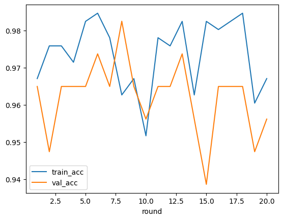

```python
# TODO

# 2. Train a SGDClassifier for 20 rounds with partial_fit, logging
#    train/val accuracy each round. Plot both curves.

from sklearn.linear_model import SGDClassifier
from sklearn.preprocessing import StandardScaler

scaler = StandardScaler().fit(Xtr)
Xtr_s, Xte_s = scaler.transform(Xtr), scaler.transform(Xte)
classes = np.unique(y)

sgd = SGDClassifier(random_state=42)
history = []
for round_ in range(1, 21):
    sgd.partial_fit(Xtr_s, ytr, classes=classes)
    history.append({
        "round": round_,
        "train_acc": sgd.score(Xtr_s, ytr),
        "val_acc": sgd.score(Xte_s, yte),
    })

hist_df = pd.DataFrame(history)
log_run("sgd_partial_fit", {"rounds": 20},
        {"final_val_acc": hist_df["val_acc"].iloc[-1]},
        notes=json.dumps(history))

hist_df.plot(x="round", y=["train_acc", "val_acc"])
plt.show()
```

```python
# TODO

# 3. Write load_all_runs() -> DataFrame of every run in runs/, sorted by
#    val_accuracy (highest first).

def load_all_runs():
    rows = []
    for f in RUNS_DIR.glob("*.json"):
        run = json.loads(f.read_text())
        row = {"name": run["name"], "time": run["time"]}
        row.update(run.get("hyperparams", {}))
        row.update(run.get("metrics", {}))
        rows.append(row)
    return pd.DataFrame(rows)

runs_df = load_all_runs()
runs_df.sort_values("val_accuracy", ascending=False).head(3)
```

|  | name | time | n_estimators | max_depth | min_samples_split | seed | train_accuracy | val_accuracy | train_time_s | rounds | final_val_acc |
| --- | --- | --- | --- | --- | --- | --- | --- | --- | --- | --- | --- |
| 0 | rf_full_record | 2026-08-10T09:24:27 | 100.0 | 8.0 | 2.0 | 42.0 | 1.0 | 0.964912 | 0.273 | NaN | NaN |
| 2 | baseline_rf | 2026-08-10T09:24:26 | 50.0 | NaN | NaN | 42.0 | NaN | 0.940000 | 0.400 | NaN | NaN |
| 1 | sgd_partial_fit | 2026-08-10T09:24:27 | NaN | NaN | NaN | NaN | NaN | NaN | NaN | 20.0 | 0.95614 |

```python
# TODO

# 4. Save one run's model, config, and metrics into its own folder instead
#    of one flat JSON file, e.g. runs/2026-08-09_rf-baseline_seed42/.

def make_run_dir(name, seed):
    stamp = datetime.now().strftime("%Y-%m-%d")
    run_dir = RUNS_DIR / f"{stamp}_{name}_seed{seed}"
    run_dir.mkdir(parents=True, exist_ok=True)
    return run_dir

run_dir = make_run_dir("rf-baseline", 42)
(run_dir / "config.json").write_text(json.dumps(hyperparams, indent=2))
(run_dir / "metrics.json").write_text(json.dumps(metrics, indent=2))

import joblib
joblib.dump(model, run_dir / "model.joblib")
print(run_dir)
```

```
/kaggle/working/runs/2026-08-10_rf-baseline_seed42
```

# 7. Experiment Tracking with TrackIO

Local JSON files (Section 6) work, but you built all the plumbing yourself — no dashboard, no charts, no easy way to compare 20 runs at a glance. **[TrackIO](https://github.com/gradio-app/trackio)** is a lightweight, **local-first** experiment tracker from Hugging Face: no account, no API key, no internet required — it stores runs in a local SQLite database and gives you a Gradio dashboard to browse them. Its API is intentionally almost identical to Weights & Biases (Section 14), so `trackio.init/log/finish` should look familiar once you get there — the difference is entirely about **where the data lives**: on your machine (TrackIO) vs. a hosted service (W&B).

### Learning Outcomes

- Log a run's config and metrics with TrackIO, with no account setup.
- Log a metric at every step of training to get a real curve, not one point.
- Compare several logged runs against each other.
- Fire an alert automatically when a metric crosses a threshold.

```python
!pip install -q trackio
```

[output not shown]

```python
import trackio

trackio.init(project="stt-ai-breast-cancer", name="rf-baseline",
             config={"n_estimators": 100, "max_depth": 8, "seed": 42})

model = RandomForestClassifier(n_estimators=100, max_depth=8, random_state=42).fit(Xtr, ytr)

trackio.log({"train_acc": model.score(Xtr, ytr), "val_acc": model.score(Xte, yte)})
trackio.finish()
print("Run logged.")
```

```
* Trackio project initialized: stt-ai-breast-cancer
* Trackio metrics logged to: /root/.cache/huggingface/trackio
* psutil detected, enabling automatic CPU/system metrics logging
* Created new run: rf-baseline
```

[interactive chart not shown]

```
* Run finished. Uploading logs to Trackio (please wait...)
Run logged.
```

```python
# TODO

# 1. ONE TrackIO run (trackio.init once): train a GradientBoostingClassifier,
#    sweeping n_estimators from 10 to 100 in steps of 10. At each step, call
#    trackio.log({...}, step=n_estimators) with train_accuracy and
#    test_accuracy. trackio.finish() once at the end. This is the difference
#    between Section 6's "log the final number" and "log a curve".

from sklearn.ensemble import GradientBoostingClassifier

trackio.init(project="stt-ai-breast-cancer", name="gb-curve", config={"model": "gb"})
for n_est in range(10, 110, 10):
    gb = GradientBoostingClassifier(n_estimators=n_est, random_state=42).fit(Xtr, ytr)
    trackio.log({
        "train_accuracy": gb.score(Xtr, ytr),
        "test_accuracy": gb.score(Xte, yte),
    }, step=n_est)
trackio.finish()
print("Curve logged - open the dashboard (below) to see it plotted.")
```

```
* Created new run: gb-curve
* Run finished. Uploading logs to Trackio (please wait...)
Curve logged - open the dashboard (below) to see it plotted.
```

```
* Created new run: dt-overfit-sweep
[TRACKIO ERROR] Overfitting detected!: gap=0.059 at depth=6 (step 6)
[TRACKIO ERROR] Overfitting detected!: gap=0.053 at depth=7 (step 7)
[TRACKIO ERROR] Overfitting detected!: gap=0.053 at depth=8 (step 8)
[TRACKIO ERROR] Overfitting detected!: gap=0.053 at depth=9 (step 9)
[TRACKIO ERROR] Overfitting detected!: gap=0.053 at depth=10 (step 10)
[TRACKIO ERROR] Overfitting detected!: gap=0.053 at depth=11 (step 11)
[TRACKIO ERROR] Overfitting detected!: gap=0.053 at depth=12 (step 12)
[TRACKIO ERROR] Overfitting detected!: gap=0.053 at depth=13 (step 13)
[TRACKIO ERROR] Overfitting detected!: gap=0.053 at depth=14 (step 14)
[TRACKIO ERROR] Overfitting detected!: gap=0.053 at depth=15 (step 15)
[TRACKIO ERROR] Overfitting detected!: gap=0.053 at depth=16 (step 16)
[TRACKIO ERROR] Overfitting detected!: gap=0.053 at depth=17 (step 17)
[TRACKIO ERROR] Overfitting detected!: gap=0.053 at depth=18 (step 18)
[TRACKIO ERROR] Overfitting detected!: gap=0.053 at depth=19 (step 19)
[TRACKIO ERROR] Overfitting detected!: gap=0.053 at depth=20 (step 20)
* Run finished. Uploading logs to Trackio (please wait...)
```

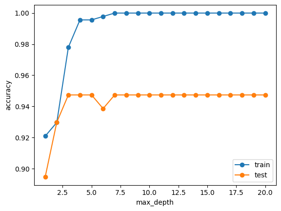

```python
# TODO

# 2. Sweep max_depth 1-20 for a DecisionTreeClassifier, log the overfit gap,
#    alert if gap > 0.05, then plot train vs test accuracy vs depth.

from sklearn.tree import DecisionTreeClassifier

trackio.init(project="stt-ai-breast-cancer", name="dt-overfit-sweep", config={"model": "dt"})

depths, train_accs, test_accs, gaps = [], [], [], []
for depth in range(1, 21):
    dt = DecisionTreeClassifier(max_depth=depth, random_state=42).fit(Xtr, ytr)
    train_acc, test_acc = dt.score(Xtr, ytr), dt.score(Xte, yte)
    gap = train_acc - test_acc

    trackio.log({"max_depth": depth, "train_accuracy": train_acc,
                "test_accuracy": test_acc, "overfit_gap": gap}, step=depth)
    if gap > 0.05:
        trackio.alert(title="Overfitting detected!", text=f"gap={gap:.3f} at depth={depth}",
                      level=trackio.AlertLevel.ERROR)

    depths.append(depth); train_accs.append(train_acc); test_accs.append(test_acc); gaps.append(gap)

trackio.finish()

plt.plot(depths, train_accs, marker="o", label="train")
plt.plot(depths, test_accs, marker="o", label="test")
plt.xlabel("max_depth"); plt.ylabel("accuracy"); plt.legend()
plt.show()
```

```python
# TODO

# 3. Log 5 classifiers (LogisticRegression, DecisionTreeClassifier,
#    RandomForestClassifier, GradientBoostingClassifier, and an SVM inside a
#    Pipeline with StandardScaler) as 5 SEPARATE TrackIO runs. For each, log
#    cv_accuracy (5-fold), test_accuracy, and fit_time_s. Print a leaderboard
#    DataFrame sorted by cv_accuracy - build it from values computed locally
#    in Python, not by reading them back from TrackIO (its API is for
#    browsing/managing runs, not a metrics database you query from code).

from sklearn.linear_model import LogisticRegression
from sklearn.svm import SVC
from sklearn.pipeline import Pipeline
from sklearn.model_selection import cross_val_score

model_zoo = {
    "LogisticRegression": LogisticRegression(max_iter=5000, random_state=42),
    "DecisionTree":       DecisionTreeClassifier(max_depth=5, random_state=42),
    "RandomForest":       RandomForestClassifier(n_estimators=100, random_state=42),
    "GradientBoosting":   GradientBoostingClassifier(n_estimators=100, random_state=42),
    "SVM":                Pipeline([("scaler", StandardScaler()), ("svm", SVC(random_state=42))]),
}

leaderboard = []
for name, clf in model_zoo.items():
    trackio.init(project="stt-ai-breast-cancer", name=f"leaderboard-{name}", config={"model": name})
    t0 = time.time()
    clf.fit(Xtr, ytr)
    fit_time = time.time() - t0
    cv_acc = cross_val_score(clf, Xtr, ytr, cv=5).mean()
    test_acc = clf.score(Xte, yte)
    trackio.log({"cv_accuracy": cv_acc, "test_accuracy": test_acc, "fit_time_s": fit_time})
    trackio.finish()
    leaderboard.append({"model": name, "cv_accuracy": cv_acc,
                        "test_accuracy": test_acc, "fit_time_s": fit_time})

pd.DataFrame(leaderboard).sort_values("cv_accuracy", ascending=False)
```

```
* Created new run: leaderboard-LogisticRegression
* Run finished. Uploading logs to Trackio (please wait...)
* Created new run: leaderboard-DecisionTree
* Run finished. Uploading logs to Trackio (please wait...)
* Created new run: leaderboard-RandomForest
* Run finished. Uploading logs to Trackio (please wait...)
* Created new run: leaderboard-GradientBoosting
* Run finished. Uploading logs to Trackio (please wait...)
* Created new run: leaderboard-SVM
* Run finished. Uploading logs to Trackio (please wait...)
```

|  | model | cv_accuracy | test_accuracy | fit_time_s |
| --- | --- | --- | --- | --- |
| 4 | SVM | 0.973626 | 0.982456 | 0.011417 |
| 0 | LogisticRegression | 0.956044 | 0.956140 | 0.628755 |
| 2 | RandomForest | 0.956044 | 0.964912 | 0.261352 |
| 3 | GradientBoosting | 0.951648 | 0.956140 | 0.823639 |
| 1 | DecisionTree | 0.925275 | 0.947368 | 0.017197 |

### Launch the dashboard

Run the cell below and open the printed URL to see every run from this section, including the training curve and the overfit-gap alert. On Kaggle, `open_browser=False` avoids trying to open a local browser window that doesn't exist in the notebook environment — copy the printed URL into a new browser tab instead.

```python
trackio.show(project="stt-ai-breast-cancer", open_browser=False, block_thread=False)
print("Dashboard starting - open the printed URL above in your browser.")
```

[interactive chart not shown]

```
Dashboard starting - open the printed URL above in your browser.
```

# 8. Parameters vs Hyperparameters

This difference confuses many students, so be clear:

|  | **Parameters** | **Hyperparameters** |
| --- | --- | --- |
| Who sets them | the training process | **you**, before training |
| Examples | weights, biases, split points in a tree | learning rate, `max_depth`, batch size, number of trees |
| When fixed | after training | before training |

### Learning Outcomes

- Tell parameters and hyperparameters apart for a trained model.
- Show, with a plot, how one hyperparameter changes model behaviour and where overfitting begins.

```python
m = RandomForestClassifier(n_estimators=10, max_depth=4, random_state=0).fit(X, y)

# Hyperparameters: what YOU chose
print("Hyperparameters:", {k: m.get_params()[k]
                           for k in ["n_estimators", "max_depth", "criterion"]})

# Parameters: what TRAINING learned - here, the tree splits
total_nodes = sum(t.tree_.node_count for t in m.estimators_)
print("Learned parameters (total tree nodes):", total_nodes)
```

```
Hyperparameters: {'n_estimators': 10, 'max_depth': 4, 'criterion': 'gini'}
Learned parameters (total tree nodes): 228
```

```
['weights of a neural network layer', 'the split value at a decision tree node', 'the bias term', 'the centroids found by k-means'] ['learning rate', 'number of epochs', 'batch size', 'dropout rate', 'k in k-nearest-neighbours']
```

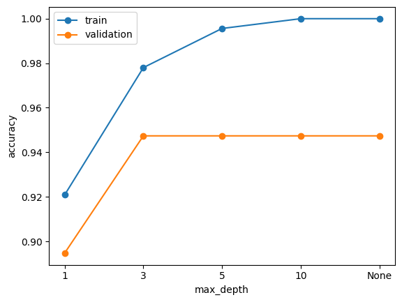

```
Best validation depth: 3
```

```python
# TODO

# 1. Sort each of these into "parameter" or "hyperparameter": learning rate,
#    weights of a neural network layer, number of epochs, the split value at
#    a decision tree node, batch size, dropout rate, the bias term, k in
#    k-nearest-neighbours, the centroids found by k-means.
parameters = ["..."]
hyperparameters = ["..."]

# 2. Train a DecisionTreeClassifier at max_depth = 1, 3, 5, 10, and None.
#    Plot train and validation accuracy against depth, and mark where
#    validation accuracy peaks and where overfitting begins.

parameters = [
    "weights of a neural network layer",
    "the split value at a decision tree node",
    "the bias term",
    "the centroids found by k-means",
]
hyperparameters = [
    "learning rate",
    "number of epochs",
    "batch size",
    "dropout rate",
    "k in k-nearest-neighbours",
]
print(parameters, hyperparameters)

from sklearn.tree import DecisionTreeClassifier

depths = [1, 3, 5, 10, None]
train_accs, val_accs = [], []
for d in depths:
    dt = DecisionTreeClassifier(max_depth=d, random_state=42).fit(Xtr, ytr)
    train_accs.append(dt.score(Xtr, ytr))
    val_accs.append(dt.score(Xte, yte))

depth_labels = [str(d) for d in depths]
plt.plot(depth_labels, train_accs, marker="o", label="train")
plt.plot(depth_labels, val_accs, marker="o", label="validation")
plt.xlabel("max_depth"); plt.ylabel("accuracy"); plt.legend()
plt.show()

best_depth = depths[int(np.argmax(val_accs))]
print("Best validation depth:", best_depth)
```

# 9. Grid Search

**Grid search** tries **every** combination of the values you list. It is simple and complete, but it grows very fast: with $k$ hyperparameters and $v$ values each, a grid needs $v^k$ combinations, each multiplied again by the number of cross-validation folds.

### Learning Outcomes

- Run a grid search with `GridSearchCV`.
- Calculate how many model fits a grid search needs before running it.
- See, with a real number, why grid search stops scaling once you have many hyperparameters.
- **Extension**: implement grid search yourself, from scratch, to see exactly what `GridSearchCV` is doing internally.

```python
from sklearn.model_selection import GridSearchCV, KFold

grid = {
    "n_estimators": [50, 100],
    "max_depth": [4, 8, None],
}
gs = GridSearchCV(RandomForestClassifier(random_state=42),
                  grid, cv=3, scoring="accuracy", n_jobs=-1)
gs.fit(Xtr, ytr)
print("Best settings:", gs.best_params_)
print("Best CV score:", round(gs.best_score_, 4))
print("Total fits:", len(gs.cv_results_["params"]) * 3)
```

```
Best settings: {'max_depth': 8, 'n_estimators': 50}
Best CV score: 0.9582
Total fits: 18
```

```
Combinations: 180
Total fits: 900
Total time: 1800 s = 30.0 min
                                      params  mean_test_score
3       {'max_depth': 8, 'n_estimators': 50}         0.958217
6      {'max_depth': 12, 'n_estimators': 50}         0.958217
9    {'max_depth': None, 'n_estimators': 50}         0.958217
0       {'max_depth': 4, 'n_estimators': 50}         0.956024
11  {'max_depth': None, 'n_estimators': 150}         0.951624
```

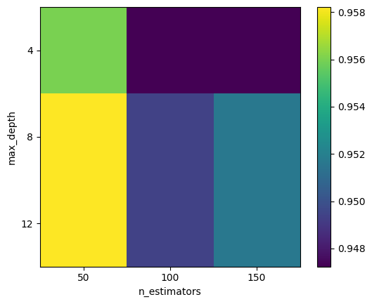

```
Combinations for 8 hyperparameters x 3 values: 6561
```

```python
# TODO

# 1. Combinations, total fits, total time for 5x4x3x3 values, 5-fold CV.

# 2. Real grid search over n_estimators/max_depth: top 5 settings + heatmap.

# 3. Recompute the combination count for 8 hyperparameters, 3 values each.

# 1.
n_estimators_vals, max_depth_vals = 5, 4
min_samples_split_vals, max_features_vals = 3, 3
cv_folds = 5

combinations = n_estimators_vals * max_depth_vals * min_samples_split_vals * max_features_vals
total_fits = combinations * cv_folds
seconds_per_fit = 2
total_time_s = total_fits * seconds_per_fit

print(f"Combinations: {combinations}")
print(f"Total fits: {total_fits}")
print(f"Total time: {total_time_s} s = {total_time_s/60:.1f} min")

# 2.
grid2 = {"n_estimators": [50, 100, 150], "max_depth": [4, 8, 12, None]}
gs2 = GridSearchCV(RandomForestClassifier(random_state=42), grid2, cv=3,
                   scoring="accuracy", n_jobs=-1)
gs2.fit(Xtr, ytr)

results = pd.DataFrame(gs2.cv_results_)
print(results.sort_values("mean_test_score", ascending=False)[
    ["params", "mean_test_score"]].head(5))

pivot = results.pivot_table(values="mean_test_score",
                            index="param_max_depth", columns="param_n_estimators")
plt.imshow(pivot, cmap="viridis"); plt.colorbar()
plt.xticks(range(len(pivot.columns)), pivot.columns)
plt.yticks(range(len(pivot.index)), pivot.index)
plt.xlabel("n_estimators"); plt.ylabel("max_depth")
plt.show()

# 3. Curse of dimensionality: 8 hyperparameters, 3 values each
print("Combinations for 8 hyperparameters x 3 values:", 3 ** 8)
# Adding a hyperparameter multiplies the total; adding values to one existing
# hyperparameter only adds a linear factor - many hyperparameters is worse.
```

```python
# TODO (Extension) - build MyGridSearchCV from scratch. GridSearchCV feels
# like magic until you build it yourself - fill in the three methods below,
# then test on breast cancer with a small DecisionTreeClassifier grid and
# compare against sklearn's GridSearchCV on the same grid.
import itertools

class MyGridSearchCV:
    def __init__(self, estimator, param_grid, cv=5, scoring="accuracy"):
        self.estimator = estimator
        self.param_grid = param_grid
        self.cv = cv
        self.scoring = scoring
        self.best_params_ = None
        self.best_score_ = -np.inf
        self.cv_results_ = []

    def _get_all_combinations(self):
        """Return a list of dicts, one per combination of self.param_grid."""
        # YOUR CODE HERE
        pass

    def _score_single_combination(self, params, X, y):
        """Run k-fold CV for one param combination using KFold directly.
        Return the mean accuracy across folds."""
        # YOUR CODE HERE
        pass

    def fit(self, X, y):
        """Run the grid search. Populate best_params_/best_score_/cv_results_."""
        # YOUR CODE HERE
        pass

    def get_results_df(self):
        return pd.DataFrame(self.cv_results_).sort_values("mean_test_score", ascending=False)


# Test on breast cancer + compare with sklearn's GridSearchCV

import itertools

class MyGridSearchCV:
    def __init__(self, estimator, param_grid, cv=5, scoring="accuracy"):
        self.estimator = estimator
        self.param_grid = param_grid
        self.cv = cv
        self.scoring = scoring
        self.best_params_ = None
        self.best_score_ = -np.inf
        self.cv_results_ = []

    def _get_all_combinations(self):
        keys = list(self.param_grid.keys())
        value_lists = list(self.param_grid.values())
        return [dict(zip(keys, combo)) for combo in itertools.product(*value_lists)]

    def _score_single_combination(self, params, X, y):
        est = self.estimator.__class__(**{**self.estimator.get_params(), **params})
        kf = KFold(n_splits=self.cv, shuffle=True, random_state=42)
        fold_scores = []
        for train_idx, val_idx in kf.split(X):
            X_train, X_val = X.iloc[train_idx], X.iloc[val_idx]
            y_train, y_val = y.iloc[train_idx], y.iloc[val_idx]
            est.fit(X_train, y_train)
            fold_scores.append(est.score(X_val, y_val))
        return np.mean(fold_scores)

    def fit(self, X, y):
        for params in self._get_all_combinations():
            mean_score = self._score_single_combination(params, X, y)
            self.cv_results_.append({"params": params, "mean_test_score": mean_score})
            if mean_score > self.best_score_:
                self.best_score_ = mean_score
                self.best_params_ = params
        return self

    def get_results_df(self):
        return pd.DataFrame(self.cv_results_).sort_values("mean_test_score", ascending=False)


param_grid_dt = {"max_depth": [2, 4, 6, 8], "min_samples_leaf": [1, 2, 4]}

my_gs = MyGridSearchCV(DecisionTreeClassifier(random_state=42), param_grid_dt, cv=5)
my_gs.fit(Xtr, ytr)
print(f"[mine]    best={my_gs.best_score_:.4f}  params={my_gs.best_params_}")

# Pass sklearn the SAME KFold object mine uses internally, rather than a plain
# cv=5. Without this, sklearn silently swaps in StratifiedKFold for
# classifiers, which is a genuinely different split - not a bug in either
# implementation, just two different (valid) CV schemes that will disagree.
same_folds = KFold(n_splits=5, shuffle=True, random_state=42)
sk_gs = GridSearchCV(DecisionTreeClassifier(random_state=42), param_grid_dt, cv=same_folds)
sk_gs.fit(Xtr, ytr)
print(f"[sklearn] best={sk_gs.best_score_:.4f}  params={sk_gs.best_params_}")
# With identical folds, both should land on the same or a very close
# best_score_ - this is the real test that MyGridSearchCV's fold loop and
# scoring logic match sklearn's, not just that both "get a good score."
```

```
[mine]    best=0.9275  params={'max_depth': 4, 'min_samples_leaf': 1}
[sklearn] best=0.9275  params={'max_depth': 4, 'min_samples_leaf': 1}
```

# 10. Random Search

**Random search** picks combinations at random from ranges you give. Surprising fact: for the same budget, it usually beats grid search, because it tests far more distinct values of whichever hyperparameter actually matters.

### Learning Outcomes

- Run a random search with `RandomizedSearchCV`.
- Compare grid and random search under the exact same fit budget.
- Choose a log-uniform range instead of a uniform one for a learning-rate-like hyperparameter.
- **Extension**: implement random search yourself, and see *where* grid vs. random search actually land in parameter space.

```python
from sklearn.model_selection import RandomizedSearchCV
from scipy.stats import randint

dist = {
    "n_estimators": randint(20, 300),
    "max_depth": randint(2, 20),
    "min_samples_split": randint(2, 20),
}
rs = RandomizedSearchCV(RandomForestClassifier(random_state=42),
                        dist, n_iter=20, cv=3, random_state=42, n_jobs=-1)
rs.fit(Xtr, ytr)
print("Best settings:", rs.best_params_)
print("Best CV score:", round(rs.best_score_, 4))
```

```
Best settings: {'max_depth': 10, 'min_samples_split': 3, 'n_estimators': 111}
Best CV score: 0.9582
```

```python
# TODO

# 1. Grid search vs random search, both exactly 20 fits. Compare best score
#    and time in a small table.

# 2. Draw 2000 samples from np.random.uniform(0.0001, 0.1) and 2000 from
#    scipy.stats.loguniform(0.0001, 0.1). Print what share of each falls
#    below 0.001 - this is why log-uniform is the better choice for
#    something like a learning rate.

# 1.
from itertools import product

grid_values = {"n_estimators": [50, 100, 150, 200], "max_depth": [4, 8, 12, None, 16]}
combos = list(product(grid_values["n_estimators"], grid_values["max_depth"]))[:20]

t0 = time.time()
grid_scores = []
for n_est, depth in combos:
    m = RandomForestClassifier(n_estimators=n_est, max_depth=depth,
                               random_state=42).fit(Xtr, ytr)
    grid_scores.append(m.score(Xte, yte))
grid_time = time.time() - t0
grid_best = max(grid_scores)

t0 = time.time()
rs20 = RandomizedSearchCV(RandomForestClassifier(random_state=42), dist, n_iter=20,
                          cv=3, random_state=42, n_jobs=-1)
rs20.fit(Xtr, ytr)
random_time = time.time() - t0

print(pd.DataFrame({
    "method": ["Grid (20 fits)", "Random (20 iter x 3-fold CV)"],
    "best_score": [grid_best, rs20.best_score_],
    "time_s": [grid_time, random_time],
}))

# 2.
from scipy.stats import loguniform

uniform_samples = np.random.uniform(0.0001, 0.1, 2000)
log_samples = loguniform.rvs(0.0001, 0.1, size=2000)

print("Uniform draws below 0.001:", (uniform_samples < 0.001).mean())
print("Log-uniform draws below 0.001:", (log_samples < 0.001).mean())
# Plain uniform draws almost never land below 0.001, so small-but-important
# learning rates are barely ever tried; log-uniform spreads draws evenly
# across orders of magnitude.
```

```
                         method  best_score    time_s
0                Grid (20 fits)    0.964912  6.813295
1  Random (20 iter x 3-fold CV)    0.958203  9.715124
Uniform draws below 0.001: 0.005
Log-uniform draws below 0.001: 0.3365
```

```python
# TODO (Extension) - build MyRandomSearchCV from scratch. Same interface as
# MyGridSearchCV, plus n_iter and random_state. Each param_distributions
# value is either a list (sample uniformly) or a scipy distribution (anything
# with .rvs(random_state=...), like randint(2, 20)). Fill in the two methods
# below, then test on breast cancer and compare against sklearn's
# RandomizedSearchCV on the same distributions.
class MyRandomSearchCV:
    def __init__(self, estimator, param_distributions, n_iter=20, cv=5,
                 scoring="accuracy", random_state=None):
        self.estimator = estimator
        self.param_distributions = param_distributions
        self.n_iter = n_iter
        self.cv = cv
        self.scoring = scoring
        self.random_state = random_state
        self.best_params_ = None
        self.best_score_ = -np.inf
        self.cv_results_ = []

    def _sample_params(self, rng):
        """One value per hyperparameter: rng.choice() for a list,
        .rvs(random_state=rng) for a scipy distribution."""
        # YOUR CODE HERE
        pass

    def fit(self, X, y):
        """Run n_iter random trials with a manual KFold loop
        (reuse the same CV logic as MyGridSearchCV)."""
        # YOUR CODE HERE
        pass

    def get_results_df(self):
        return pd.DataFrame(self.cv_results_).sort_values("mean_test_score", ascending=False)


# Test on breast cancer + compare with sklearn's RandomizedSearchCV

class MyRandomSearchCV:
    def __init__(self, estimator, param_distributions, n_iter=20, cv=5,
                 scoring="accuracy", random_state=None):
        self.estimator = estimator
        self.param_distributions = param_distributions
        self.n_iter = n_iter
        self.cv = cv
        self.scoring = scoring
        self.random_state = random_state
        self.best_params_ = None
        self.best_score_ = -np.inf
        self.cv_results_ = []

    def _sample_params(self, rng):
        params = {}
        for name, spec in self.param_distributions.items():
            if hasattr(spec, "rvs"):
                params[name] = int(spec.rvs(random_state=rng))
            else:
                params[name] = spec[rng.integers(0, len(spec))]
        return params

    def _score_single_combination(self, params, X, y):
        est = self.estimator.__class__(**{**self.estimator.get_params(), **params})
        kf = KFold(n_splits=self.cv, shuffle=True, random_state=42)
        fold_scores = []
        for train_idx, val_idx in kf.split(X):
            X_train, X_val = X.iloc[train_idx], X.iloc[val_idx]
            y_train, y_val = y.iloc[train_idx], y.iloc[val_idx]
            est.fit(X_train, y_train)
            fold_scores.append(est.score(X_val, y_val))
        return np.mean(fold_scores)

    def fit(self, X, y):
        rng = np.random.default_rng(self.random_state)
        for _ in range(self.n_iter):
            params = self._sample_params(rng)
            mean_score = self._score_single_combination(params, X, y)
            self.cv_results_.append({"params": params, "mean_test_score": mean_score})
            if mean_score > self.best_score_:
                self.best_score_ = mean_score
                self.best_params_ = params
        return self

    def get_results_df(self):
        return pd.DataFrame(self.cv_results_).sort_values("mean_test_score", ascending=False)


param_dist_dt = {
    "max_depth": [2, 4, 6, 8, 10, 15],
    "min_samples_leaf": randint(1, 10),
}

my_rs = MyRandomSearchCV(DecisionTreeClassifier(random_state=42), param_dist_dt,
                         n_iter=20, cv=5, random_state=42)
my_rs.fit(Xtr, ytr)
print(f"[mine]    best={my_rs.best_score_:.4f}  params={my_rs.best_params_}")

# Same KFold object as the Grid Search comparison above, so any remaining gap
# is purely about the sampling path (mine vs sklearn's), not the CV scheme.
sk_rs = RandomizedSearchCV(DecisionTreeClassifier(random_state=42), param_dist_dt,
                           n_iter=20, cv=same_folds, random_state=42)
sk_rs.fit(Xtr, ytr)
print(f"[sklearn] best={sk_rs.best_score_:.4f}  params={sk_rs.best_params_}")
# Unlike grid search, an exact match isn't expected here even with matched
# folds - MyRandomSearchCV and RandomizedSearchCV use different internal
# sampling implementations, so the 20 random points they draw are different
# points from the same distribution. Both scores should be in the same
# ballpark; the params found won't usually be identical.
```

```
[mine]    best=0.9275  params={'max_depth': 4, 'min_samples_leaf': 1}
[sklearn] best=0.9143  params={'max_depth': 4, 'min_samples_leaf': 3}
```

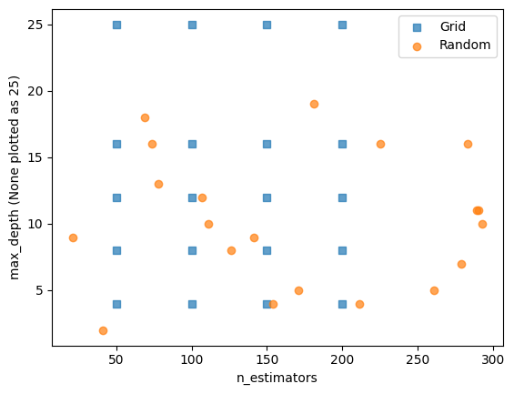

```python
# TODO (Extension) - coverage plot. Grid and random search don't just score
# differently, they land in different places in parameter space. Scatter the
# 20 grid points and the 20 random-search points from the first TODO above,
# colour-coded, on the same (n_estimators, max_depth) axes.

grid_n_est = [c[0] for c in combos]
grid_depth = [c[1] if c[1] is not None else 25 for c in combos]  # None -> plot at 25 for visibility

random_n_est = [p["n_estimators"] for p in rs20.cv_results_["params"]]
random_depth = [p["max_depth"] for p in rs20.cv_results_["params"]]

plt.scatter(grid_n_est, grid_depth, label="Grid", marker="s", alpha=0.7)
plt.scatter(random_n_est, random_depth, label="Random", marker="o", alpha=0.7)
plt.xlabel("n_estimators"); plt.ylabel("max_depth (None plotted as 25)"); plt.legend()
plt.show()
# Grid points fall on a rigid lattice - only 5 distinct max_depth values, ever.
# Random points spread continuously across the whole max_depth range, so if
# the "sweet spot" for max_depth isn't exactly one of the grid's 5 values,
# only random search can actually find it.
```

# 11. Bayesian Optimization

Grid and random search are **blind** — they never learn from earlier tries. **Bayesian optimization** builds a cheap model of "which settings look promising" from the results so far, then uses an **acquisition function** to pick the next setting to try, balancing **exploiting** (near the best known point) and **exploring** (where little is known yet).

### Learning Outcomes

- Run a Bayesian search with Optuna.
- Compare grid, random, and Bayesian search under the same budget.
- Plot the "best score so far" curve to see Bayesian search learn over trials.
- **Extension**: read which hyperparameter mattered most, confirm Optuna is itself reproducible, tune a regression model, and let Optuna choose the model family for you.

```python
!pip install -q optuna
```

```python
import optuna
from sklearn.model_selection import cross_val_score

optuna.logging.set_verbosity(optuna.logging.WARNING)

def objective(trial):
    params = {
        "n_estimators":      trial.suggest_int("n_estimators", 20, 300),
        "max_depth":         trial.suggest_int("max_depth", 2, 20),
        "min_samples_split": trial.suggest_int("min_samples_split", 2, 20),
    }
    model = RandomForestClassifier(**params, random_state=42)
    return cross_val_score(model, Xtr, ytr, cv=3).mean()

study = optuna.create_study(direction="maximize",
                            sampler=optuna.samplers.TPESampler(seed=42))
study.optimize(objective, n_trials=20)
print("Best settings:", study.best_params)
print("Best score:", round(study.best_value, 4))
```

```
Best settings: {'n_estimators': 253, 'max_depth': 6, 'min_samples_split': 5}
Best score: 0.9538
```

```
                   best_score     time_s
Grid search          0.964912   6.850107
Random search        0.958203   9.671659
Bayesian (Optuna)    0.953817  23.671229
```

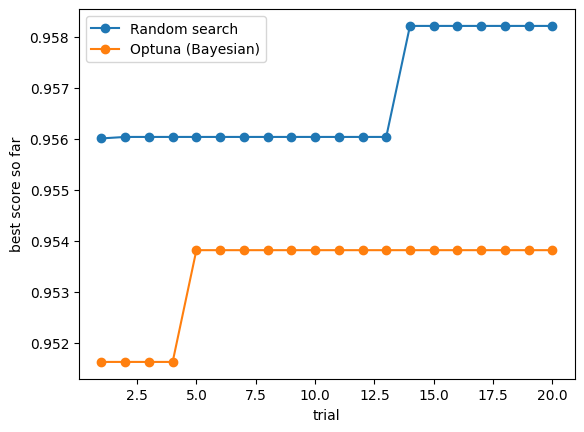

```python
# TODO

# 1. Grid vs random vs Optuna, 20 trials each, one comparison table.

# 2. Plot best-score-so-far for random search and Optuna on the same graph.

# 1.
results_82 = {}

t0 = time.time()
grid20 = list(product([50, 100, 150, 200], [4, 8, 12, None, 16]))[:20]
scores20 = [RandomForestClassifier(n_estimators=n, max_depth=d, random_state=42)
            .fit(Xtr, ytr).score(Xte, yte) for n, d in grid20]
results_82["Grid search"] = (max(scores20), time.time() - t0)

t0 = time.time()
rs = RandomizedSearchCV(RandomForestClassifier(random_state=42), dist, n_iter=20, cv=3,
                        random_state=42, n_jobs=-1).fit(Xtr, ytr)
results_82["Random search"] = (rs.best_score_, time.time() - t0)

t0 = time.time()
study20 = optuna.create_study(direction="maximize",
                              sampler=optuna.samplers.TPESampler(seed=42))
study20.optimize(objective, n_trials=20)
results_82["Bayesian (Optuna)"] = (study20.best_value, time.time() - t0)

print(pd.DataFrame(results_82, index=["best_score", "time_s"]).T)

# 2.
random_param_draws = [
    dict(n_estimators=int(a), max_depth=int(b), min_samples_split=int(c))
    for a, b, c in zip(np.random.randint(20, 300, 20),
                       np.random.randint(2, 20, 20),
                       np.random.randint(2, 20, 20))
]
random_trial_scores = [
    cross_val_score(RandomForestClassifier(**p, random_state=42), Xtr, ytr, cv=3).mean()
    for p in random_param_draws
]
random_best_so_far = np.maximum.accumulate(random_trial_scores)
optuna_best_so_far = np.maximum.accumulate([t.value for t in study20.trials])

plt.plot(range(1, 21), random_best_so_far, marker="o", label="Random search")
plt.plot(range(1, 21), optuna_best_so_far, marker="o", label="Optuna (Bayesian)")
plt.xlabel("trial"); plt.ylabel("best score so far"); plt.legend()
plt.show()
```

```
{'max_depth': np.float64(0.5575685746312921), 'min_samples_split': np.float64(0.3274357242530612), 'n_estimators': np.float64(0.11499570111564669)}
```

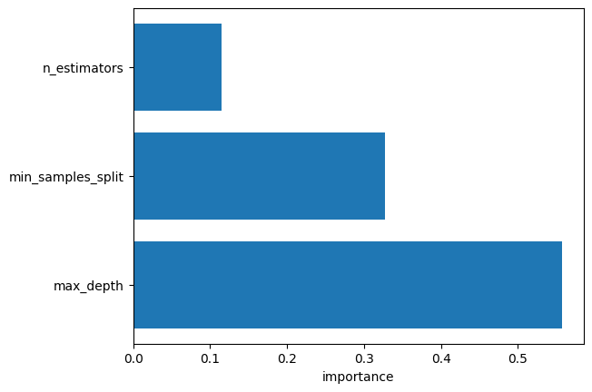

```python
# TODO (Extension) - parameter importance. Optuna can compute how much each
# hyperparameter contributed to the score variance across your `study` from
# above. Print optuna.importance.get_param_importances(study) and plot a
# horizontal bar chart (param name on y-axis, importance on x-axis).

importances = optuna.importance.get_param_importances(study)
print(importances)

plt.barh(list(importances.keys()), list(importances.values()))
plt.xlabel("importance")
plt.show()
```

```python
# TODO (Extension) - is Optuna itself reproducible? Run two fresh studies
# with the exact same objective, n_trials=10, and TPESampler(seed=42).
# Extract [t.value for t in study.trials] from each and assert they are
# equal. What does this prove - and where would it break?

study_a = optuna.create_study(direction="maximize", sampler=optuna.samplers.TPESampler(seed=42))
study_a.optimize(objective, n_trials=10)

study_b = optuna.create_study(direction="maximize", sampler=optuna.samplers.TPESampler(seed=42))
study_b.optimize(objective, n_trials=10)

values_a = [t.value for t in study_a.trials]
values_b = [t.value for t in study_b.trials]
assert values_a == values_b, "Studies diverged!"
print("Identical trial sequences:", values_a == values_b)
# This proves Optuna's own trial-selection process is seeded and deterministic
# - same sampler seed, same objective, same 10 trials in the same order. It
# would break if the objective itself is non-deterministic (e.g. an unseeded
# model inside it), or if trials ran in parallel with n_jobs>1, where trial
# completion order (and therefore what the sampler has seen so far) can vary.
```

```
Identical trial sequences: True
```

```python
# TODO (Extension) - a regression task. Everything so far has been
# classification; switch to regression. Tune GradientBoostingRegressor on the
# California Housing dataset (built into scikit-learn, downloaded on first
# use - needs Internet On). Minimise RMSE, 20 trials. n_estimators 50-300,
# learning_rate log-uniform 1e-3 to 1.0, max_depth 2-8.

from sklearn.datasets import fetch_california_housing
from sklearn.ensemble import GradientBoostingRegressor
from sklearn.metrics import mean_squared_error

housing = fetch_california_housing(as_frame=True)
Xh, yh = housing.data, housing.target
Xh_tr, Xh_te, yh_tr, yh_te = train_test_split(Xh, yh, test_size=0.2, random_state=42)

def objective_housing(trial):
    params = {
        "n_estimators":  trial.suggest_int("n_estimators", 50, 300),
        "learning_rate": trial.suggest_float("learning_rate", 1e-3, 1.0, log=True),
        "max_depth":     trial.suggest_int("max_depth", 2, 8),
    }
    model = GradientBoostingRegressor(**params, random_state=42)
    model.fit(Xh_tr, yh_tr)
    return mean_squared_error(yh_te, model.predict(Xh_te)) ** 0.5  # RMSE

study_housing = optuna.create_study(direction="minimize",
                                    sampler=optuna.samplers.TPESampler(seed=42))
study_housing.optimize(objective_housing, n_trials=20)
print("Best RMSE  :", round(study_housing.best_value, 4))
print("Best params:", study_housing.best_params)
```

```
Best RMSE  : 0.4503
Best params: {'n_estimators': 252, 'learning_rate': 0.12356971289592052, 'max_depth': 7}
```

```python
# TODO (Extension) - let Optuna pick the model family. Use
# trial.suggest_categorical to let Optuna choose both the model family AND
# its hyperparameters in a single study - a tiny hand-rolled AutoML. Include
# DecisionTree, RandomForest, and KNN. Run 30 trials on the breast cancer
# data, then count how many trials picked each family.
def objective_automl(trial):
    classifier = trial.suggest_categorical("classifier", ["DT", "RF", "KNN"])
    # if classifier == "DT": suggest DT params, build DecisionTreeClassifier
    # elif classifier == "RF": suggest RF params, build RandomForestClassifier
    # elif classifier == "KNN": suggest KNN params, build KNeighborsClassifier
    # return 5-fold CV accuracy on Xtr, ytr
    pass

# Run 30 trials, print best, then count how often each family was chosen.

from sklearn.neighbors import KNeighborsClassifier

def objective_automl(trial):
    classifier = trial.suggest_categorical("classifier", ["DT", "RF", "KNN"])
    if classifier == "DT":
        model = DecisionTreeClassifier(max_depth=trial.suggest_int("dt_max_depth", 2, 20),
                                       random_state=42)
    elif classifier == "RF":
        model = RandomForestClassifier(n_estimators=trial.suggest_int("rf_n_estimators", 20, 200),
                                       max_depth=trial.suggest_int("rf_max_depth", 2, 20),
                                       random_state=42)
    else:
        model = KNeighborsClassifier(n_neighbors=trial.suggest_int("knn_n_neighbors", 1, 20))
    return cross_val_score(model, Xtr, ytr, cv=5).mean()

study_automl = optuna.create_study(direction="maximize",
                                   sampler=optuna.samplers.TPESampler(seed=42))
study_automl.optimize(objective_automl, n_trials=30)
print("Best value :", round(study_automl.best_value, 4))
print("Best params:", study_automl.best_params)

chosen = pd.Series([t.params["classifier"] for t in study_automl.trials]).value_counts()
print("\nTimes each family was chosen:")
print(chosen)
```

```
Best value : 0.9626
Best params: {'classifier': 'RF', 'rf_n_estimators': 155, 'rf_max_depth': 17}

Times each family was chosen:
RF     20
KNN     5
DT      5
Name: count, dtype: int64
```

# 12. Data Leakage & Pipelines

*(Extension section)*

**Data leakage** happens when information from outside the training fold sneaks into training — most commonly by fitting a preprocessing step (like scaling) on the **whole** dataset before cross-validation, so every "unseen" validation fold has already influenced the scaler. The fix is to put preprocessing **inside** a `Pipeline`, so it gets refit on only the training fold at every step of cross-validation.

### Learning Outcomes

- See data leakage inflate a CV score with your own eyes.
- Fix it with a `Pipeline`, and explain why that fixes it.
- Tune a `Pipeline` end-to-end with `GridSearchCV`.

```python
from sklearn.svm import SVC
from sklearn.pipeline import Pipeline

# --- WRONG: scale before CV (leaky) ---
scaler = StandardScaler()
X_scaled = scaler.fit_transform(X)  # sees ALL data, including future validation folds!

leaky_score = cross_val_score(
    SVC(C=1, kernel="rbf", random_state=42), X_scaled, y, cv=5
).mean()

# --- RIGHT: scale inside a Pipeline ---
pipe = Pipeline([
    ("scaler", StandardScaler()),
    ("svm", SVC(C=1, kernel="rbf", random_state=42)),
])
correct_score = cross_val_score(pipe, X, y, cv=5).mean()

print(f"Leaky  (wrong)    CV accuracy: {leaky_score:.4f}")
print(f"Correct (Pipeline) CV accuracy: {correct_score:.4f}")
print(f"Difference: {leaky_score - correct_score:+.4f}")
if abs(leaky_score - correct_score) < 0.005:
    print("(Small or zero gap here - breast cancer has 569 fairly stable rows, so a "
          "per-fold scaler and a whole-dataset scaler end up with nearly identical "
          "mean/std anyway. The leak is still real; it just doesn't move the needle "
          "much on this particular dataset. The Pipeline fix costs nothing, so use it "
          "regardless of whether the gap happens to be visible - on a smaller dataset, "
          "or with a leakier step like selecting features by correlation with the "
          "label, the same mistake can inflate scores by many points.)")
```

[output not shown]

The direction is always the same — leaky ≥ correct, never the other way around — but the *size* of the gap depends on the dataset, as the printout above just showed you.

```python
# TODO

# 1. One sentence: why does fitting StandardScaler on the whole dataset
#    before cross_val_score leak information from the validation folds?
answer = "..."

# 2. Build Pipeline(StandardScaler -> SVC) and tune it with GridSearchCV on
#    the breast cancer data. svm__C: [0.01, 0.1, 1, 10, 100],
#    svm__kernel: ["linear", "rbf"] - note the svm__ prefix, needed because
#    "svm" is the pipeline step's name.

answer = (
    "The scaler's mean and standard deviation are computed from every row, "
    "including the ones that later become a validation fold - so each fold's "
    "'unseen' data already shaped the scaling applied to it, inflating the score."
)
print(answer)

param_grid_pipe = {
    "svm__C": [0.01, 0.1, 1, 10, 100],
    "svm__kernel": ["linear", "rbf"],
}

pipe2 = Pipeline([("scaler", StandardScaler()), ("svm", SVC(random_state=42))])
gs_pipe = GridSearchCV(pipe2, param_grid_pipe, cv=5)
gs_pipe.fit(Xtr, ytr)

print(f"Best params : {gs_pipe.best_params_}")
print(f"Best CV score: {gs_pipe.best_score_:.4f}")
```

```
The scaler's mean and standard deviation are computed from every row, including the ones that later become a validation fold - so each fold's 'unseen' data already shaped the scaling applied to it, inflating the score.
Best params : {'svm__C': 0.1, 'svm__kernel': 'linear'}
Best CV score: 0.9736
```

# 13. AutoML and AutoGluon

**AutoML** automates the whole pipeline: it cleans features, tries several model families, tunes them, and often blends the best ones together — preprocessing → model selection → hyperparameter tuning → ensembling, with no per-model code from you. (Section 11's Extension had you build a tiny version of this by hand with `suggest_categorical` — this is the industrial-strength version.)

> **Timing note:** `pip install autogluon.tabular` pulls in several ML frameworks and can take 5-15 minutes depending on what's cached. Start the install, keep working while it runs, and come back to `predictor.fit(...)` once it's done — don't block the room waiting on it.